# YouTube Analysis Final Project

James Corley

5/18/2018

## Background

YouTube is a huge video-sharing website that has been around since 2005. YouTube offers a series of tools and a platform for creators to express anything they could imagine. YouTube doesn’t actually produce the content that is on its site, but simply offers it for free for anyone to use. On this platform, there exist thousands of hours of videos that range from informational to entertaining. All of these videos come from the content creators on YouTube, uploading their videos for the world to see.

YouTube has stated that, on average, they receive 30 million visitors per day. With such a huge audience, many new “YouTubers” try to make content to capture a part of this audience. If a content creator gains enough of a following, YouTube will start to pay the creator for the advertisements shown at the beginning of their videos. The following of a YouTuber is typically gauged by their “subscribers”, the people who subscribe to a channel (get updates when they release videos), and “views”, which is just the amount of times any video is seen by a user.

In this project, I will be examining the top 250 United States YouTubers based on subscribers. I will look at their growth (and possibly decline) and try to understand if there is a logical reason behind their success.

## Data Curation and Tidying

To start our process, we will be scraping data from [Social Blade](https://socialblade.com/). This website offers a huge amount of data on thousands of social media accounts across many different platforms (Twitch, YouTube, Twitter, Instagram). For this project, we will just be focusing on the YouTube section of their data.

In addition to the variety of data, Social Blade also offers many different subsets of their YouTuber data. We can choose to select by country, ranked by total views, subscribers, or a custom rank that is defined by their system. This project will be focusing on the top United States YouTubers, determined by their total subscribers.

We’ll start by getting all links from this page (there are no unique identifiers for the YouTubers and the data is not wrapped in a table).

```r
url <- 'https://socialblade.com/youtube/top/country/us/mostsubscribed'

links <- url %>%
  read_html() %>%
  html_nodes("a") %>%
  html_attr("href")
```

Next, we’ll filter out the links that don’t correspond to a YouTube channel, then trim out the unneeded characters at the beginning of each URL.

```r
youtube_tbl <- data.frame(link = links) %>%
  filter(grepl('/youtube/user', link)) %>%
  sapply(substring, 15)
```

This next step will now go through the links for each YouTuber, grabbing statistics about their channel name, total subscribers, total view, total uploads, creation date, monthly average views, subscribers, and the frequency of their uploads (per day). The first four are under specific identifiers, but the date field and averages don’t have a specific identifier. In order to get this data, we will manually select and trim the fields. This date field also needs some tidying, so it is cleaned up to fit the proper date format. The averages also have commas and `+/-` infront of the numbers, so lets remove those too.

**NOTE: This will take some time as it does ~500 different page requests. I’d recommend running this once and possibly saving the result.**

```r
col_names <- c("name",
               "subscribers",
               "total_views",
               "uploads",
               "creation_date",
               "daily_subs_avg",
               "daily_views_avg")

temp_tbl <- matrix(ncol=length(col_names), nrow=length(youtube_tbl))

for (i in 1:length(youtube_tbl)) {
  url <- str_c("https://socialblade.com/youtube/user/", youtube_tbl[i])

  data <- url %>%
    read_html()

  name <- data %>%
    html_node("h1") %>%
    html_text()

  uploads <- data %>%
    html_node("#youtube-stats-header-uploads") %>%
    html_text() %>%
    as.integer()

  subs <- data %>%
    html_node("#youtube-stats-header-subs") %>%
    html_text() %>%
    as.integer()

  views <- data %>%
    html_node("#youtube-stats-header-views") %>%
    html_text() %>%
    as.double()

  creation_date <- data %>%
    html_nodes("#YouTubeUserTopInfoBlock div:nth-child(7)") %>%
    html_text() %>%
    substring(13)

  creation_date <- gsub("nd", "", creation_date)
  creation_date <- gsub("th", "", creation_date)
  creation_date <- gsub("st", "", creation_date)

  url <- str_c("https://socialblade.com/youtube/user/", youtube_tbl[i], "/monthly")

  data <- url %>%
    read_html() %>%
    html_nodes("body > div:nth-child(18) > div > div:nth-child(1) > div:nth-child(35)")

  daily_subs_avg <- data %>%
    html_node("div:nth-child(2)") %>%
    html_text() %>%
    substring(2)

  daily_views_avg <- data %>%
    html_nodes("div:nth-child(3)") %>%
    html_text()

  daily_views_avg <- daily_views_avg[2] %>%
    substring(2)

  daily_subs_avg <- gsub("\\+", "", daily_subs_avg) %>% trimws()
  daily_subs_avg <- gsub(",", "", daily_subs_avg)

  daily_views_avg <- gsub("\\+", "", daily_views_avg) %>% trimws()
  daily_views_avg <- gsub(",", "", daily_views_avg)

  if (is.na(daily_subs_avg) || is_empty(daily_subs_avg)) {
    daily_subs_avg <- 0
  }

  if (is.na(daily_subs_avg) || is_empty(daily_views_avg)) {
    daily_views_avg <- 0
  }

  temp_tbl[i,] = c(name, subs, views, uploads, creation_date, daily_subs_avg, daily_views_avg)
}

youtube_tbl <- data.frame(temp_tbl)
colnames(youtube_tbl) <- col_names

youtube_tbl <- youtube_tbl %>%
  mutate(upload_freq=as.numeric(uploads/(Sys.Date() - as.Date(creation_date, format="%b %d, %Y"))))

youtube_tbl %>% head()
```

```
##               name subscribers total_views uploads creation_date
## 1        PewDiePie    62686815 17798661815    3508  Apr 29, 2010
## 2 JustinBieberVEVO    34533162 17345413052     123  Sep 26, 2009
## 3     Dude Perfect    30229156  5200151713     176  Mar 17, 2009
## 4     Taylor Swift    30007800   208882737     161  Sep 20, 2006
## 5       Katy Perry    29553517   351507334      92   Jun 1, 2008
## 6      EminemMusic    28617416   264611237     101   Feb 9, 2007
##   daily_subs_avg daily_views_avg  upload_freq
## 1          15909         6783810 0.0414824889
## 2          -2335         3954670 0.0079214195
## 3          30729         5855930 0.0158256196
## 4          10753          111268 0.0105683419
## 5          14361           23721 0.0574491479
## 6          11713           31672 0.0004859086
```

This last step is meant to clean up all of the data that was previously gathered. Each column is cast into its proper type, making the visualization much easier later in the project. The only columns that have `NA` as a value are the YouTube official channels (YouTube Music, etc.). These channels are a little different than normal channels anyway, so this ommission should not impact our analysis.

```r
youtube_final_tbl <- youtube_tbl

youtube_final_tbl$name <- as.character(youtube_final_tbl$name)
youtube_final_tbl$subscribers <- as.numeric(as.character(youtube_final_tbl$subscribers))
youtube_final_tbl$total_views <- as.numeric(as.character(youtube_final_tbl$total_views))
youtube_final_tbl$uploads <- as.numeric(as.character(youtube_final_tbl$uploads))
youtube_final_tbl$creation_date <- youtube_final_tbl$creation_date %>%
  as.Date(format="%b %d, %Y")

youtube_final_tbl$daily_subs_avg <- as.numeric(as.character(youtube_final_tbl$daily_subs_avg))
youtube_final_tbl$daily_views_avg <- as.numeric(as.character(youtube_final_tbl$daily_views_avg))

youtube_final_tbl <- na.omit(youtube_final_tbl)

youtube_final_tbl %>% head()
```

```
##               name subscribers total_views uploads creation_date
## 1        PewDiePie    62686815 17798661815    3508    2010-04-29
## 2 JustinBieberVEVO    34533162 17345413052     123    2009-09-26
## 3     Dude Perfect    30229156  5200151713     176    2009-03-17
## 4     Taylor Swift    30007800   208882737     161    2006-09-20
## 5       Katy Perry    29553517   351507334      92    2008-06-01
## 6      EminemMusic    28617416   264611237     101    2007-02-09
##   daily_subs_avg daily_views_avg  upload_freq
## 1          15909         6783810 0.0414824889
## 2          -2335         3954670 0.0079214195
## 3          30729         5855930 0.0158256196
## 4          10753          111268 0.0105683419
## 5          14361           23721 0.0574491479
## 6          11713           31672 0.0004859086
```

## Exploratory Data Analysis

Now that we have a full tidy dataset, we can start to examine the skew, variance and central tendacies of this data. This will assist in validaing the results of our analysis later.

We can start by determining the range of our data, the YouTuber with the most/least subscribers, most/least views, and most/least uploads.

```r
youtube_final_tbl %>%
  summarize(min_subscribers=min(subscribers), max_subscribers=max(subscribers),
            min_total_views=min(total_views), max_total_views=max(total_views),
            min_uploads=min(uploads), max_uploads=max(uploads))
```

```
##   min_subscribers max_subscribers min_total_views max_total_views
## 1         5977947        62686815          966819     22720751854
##   min_uploads max_uploads
## 1           0      127094
```

Looking at this table, we can see our subscribers range is quite large, from ~6 million to ~62 million. This also is especially suprising as our views has an even larger range, from ~965-thousand to ~22.7 billion. It seems very odd to have a channel that has at least 6 million subscribers, but doesn’t have more than a million total video views.

Lets find this channel.

```r
youtube_final_tbl %>%
  filter(total_views <= 1000000)
```

```
##             name subscribers total_views uploads creation_date
## 1 Meghan Trainor     9341651      966819       6    2008-06-04
##   daily_subs_avg daily_views_avg upload_freq
## 1           4418            6740  0.04704264
```

```r
youtube_final_tbl <- youtube_final_tbl %>%
  within(total_views[name == "Meghan Trainor"] <- mean(youtube_final_tbl$total_views))
```

Now that I also have the power of the future, I’m going to clean up a few other special cases to make our data make more sense.

```r
youtube_final_tbl <- youtube_final_tbl %>%
  within(uploads[name == "Michael Jackson"] <- 137)  # michael jackson made 137 songs, YouTube listed 0
```

Now lets take a second look at our data’s range.

```r
youtube_final_tbl %>%
  summarize(min_subscribers=min(subscribers), max_subscribers=max(subscribers),
            min_total_views=min(total_views), max_total_views=max(total_views),
            min_uploads=min(uploads), max_uploads=max(uploads))
```

```
##   min_subscribers max_subscribers min_total_views max_total_views
## 1         5977947        62686815         6754499     22720751854
##   min_uploads max_uploads
## 1           6      127094
```

As our range is so large for many of these numbers, lets use median and mean to determine the central tendancy of our data.

```r
youtube_final_tbl %>%
  summarize(median_subscribers=median(subscribers), mean_subscribers=mean(subscribers),
            median_total_views=median(total_views), mean_total_views=mean(total_views),
            median_uploads=median(uploads), mean_uploads=mean(uploads))
```

```
##   median_subscribers mean_subscribers median_total_views mean_total_views
## 1            9793696         11449298         2718480600       3812470127
##   median_uploads mean_uploads
## 1            324     2276.958
```

Subscribers and total views in this population seem to not have a large amount of skew, however, the difference between median uploads and mean uploads seems to be very large. Lets make a boxplot to examine if there is any skew.

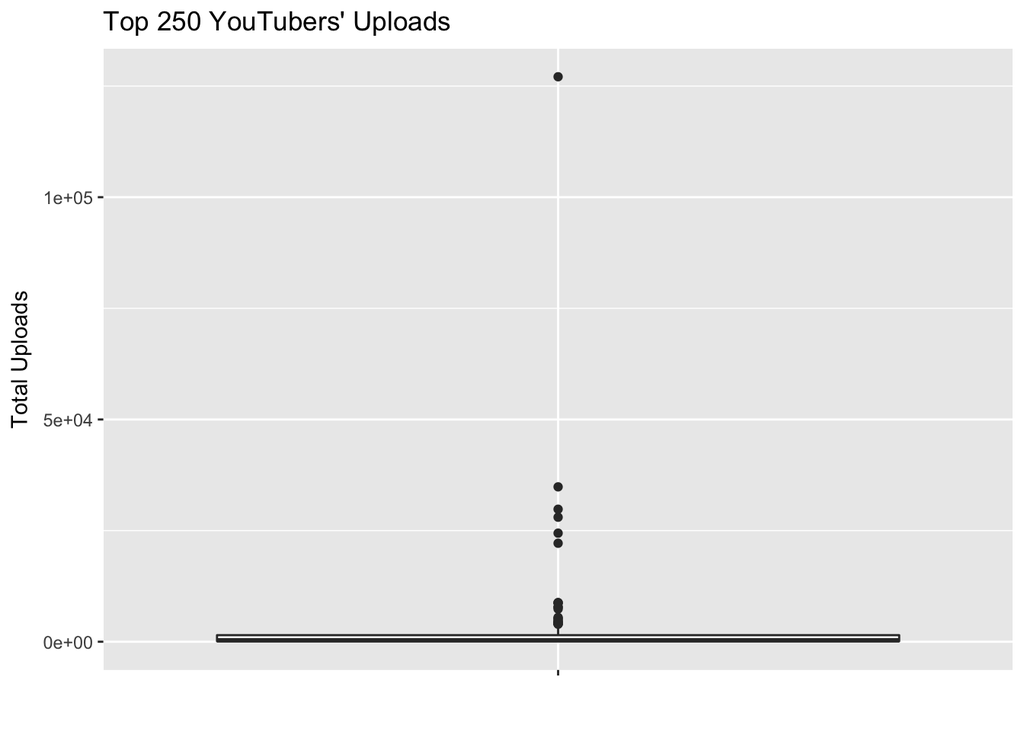

```r
youtube_final_tbl %>%
  ggplot(aes(x='', y=uploads)) +
    labs(x="", y = "Total Uploads", title = "Top 250 YouTubers' Uploads") +
    geom_boxplot()
```

This boxplot clearly shows that we have an outlier. Lets find this outlier and remove it so we can get a better look at our data.

```r
youtube_final_tbl %>%
  filter(uploads >= 50000)
```

```
##   name subscribers total_views uploads creation_date daily_subs_avg
## 1  IGN     9807748  7559830628  127094    2006-09-19           6097
##   daily_views_avg upload_freq
## 1         3662720  0.00680911
```

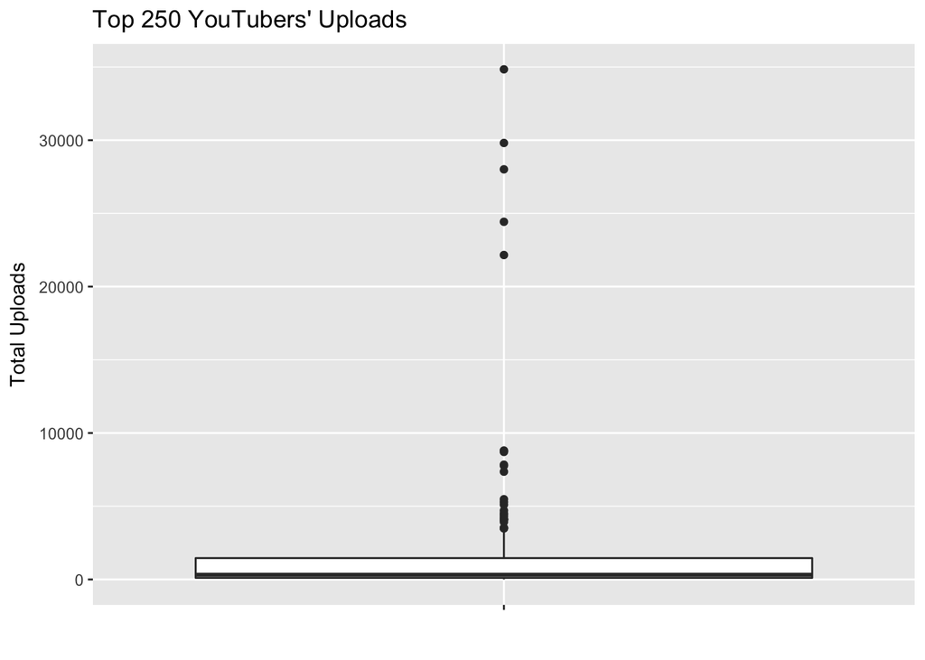

```r
youtube_final_tbl %>%
  filter(name != "IGN") %>%
  ggplot(aes(x='', y=uploads)) +
    labs(x="", y = "Total Uploads", title = "Top 250 YouTubers' Uploads") +
    geom_boxplot()
```

As we can see, we still have a very skewed dataset. In order to balance this, we will use the median for a more accurate measurement of central tendancy for top 250 YouTuber uploads.

We can now look at the views and subscribers of the top 250 YouTubers and visually compare our mesaurements of central tendancy. The mean and median for views and subscribers should be relatively closer than observed in uploads. In the plot below, the median is represented in red and the mean in blue.

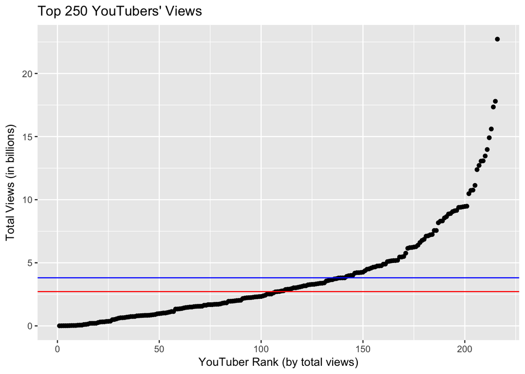

```r
youtube_final_tbl %>%
  arrange(total_views) %>%
  rowid_to_column() %>%
  ggplot(aes(x=rowid, y=total_views/1e+09)) +
    labs(x = "YouTuber Rank (by total views)", y = "Total Views (in billions)", title = "Top 250 YouTubers' Views") +
    geom_point() +
    geom_hline(aes(yintercept=median(total_views)/1e+09), color="red") +
    geom_hline(aes(yintercept=mean(total_views)/1e+09), color="blue")
```

One statistic that is very important throughout this project is the subscribers. Understanding the skew of this variable will significantly help our analysis and help us fit a model to our population of top 250 YouTubers. In the plot below, the median is represented in red and the mean in blue.

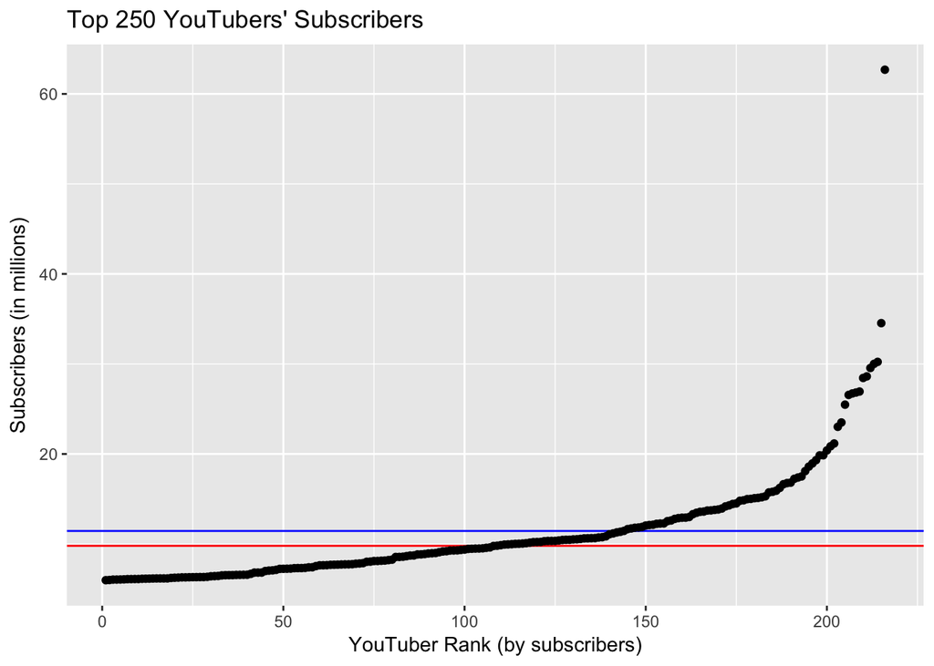

```r
youtube_final_tbl %>%
  arrange(subscribers) %>%
  rowid_to_column() %>%
  ggplot(aes(x=rowid, y=subscribers/1e+06)) +
    labs(x = "YouTuber Rank (by subscribers)", y = "Subscribers (in millions)", title = "Top 250 YouTubers' Subscribers") +
    geom_hline(aes(yintercept=median(subscribers)/1e+06), color="red") +
    geom_hline(aes(yintercept=mean(subscribers)/1e+06), color="blue") +
    geom_point()
```

Now that we have an understanding of the range, central tendancy and variance of our primary variables, we can start to test hypothesis’ on our data. The analysis of the data we have done in this section will help us understand our results, potentially explaining skewed regressions or error rates as we move forward.

## Hypothesis Testing

Lets start with a plot to examine the correlation between subscribers and total views.

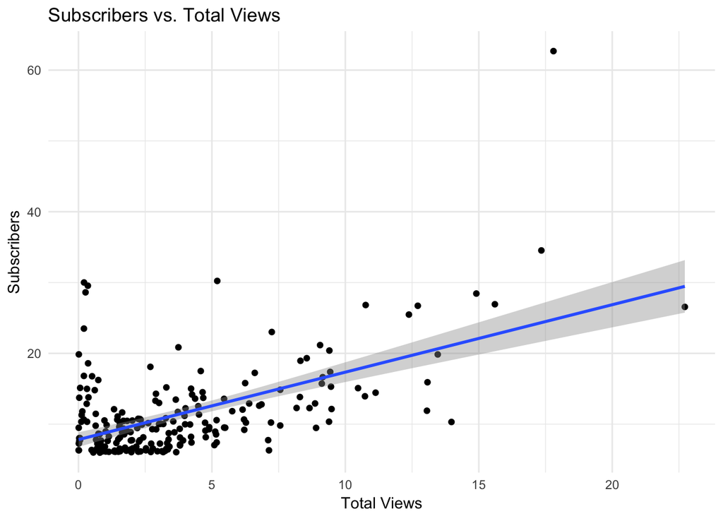

```r
youtube_final_tbl %>%
  ggplot(aes(x=total_views/1e+09, y=subscribers/1e+06)) +
  geom_point() +
  geom_smooth(method="lm") +
  theme_minimal() +
  labs(x = "Total Views", y = "Subscribers", title = "Subscribers vs. Total Views")
```

```r
lm(subscribers~total_views, data=youtube_final_tbl) %>%
  broom::tidy()
```

```
##          term     estimate    std.error statistic      p.value
## 1 (Intercept) 7.817949e+06 5.247252e+05 14.899130 6.483365e-35
## 2 total_views 9.524923e-04 9.755738e-05  9.763406 7.369357e-19
```

```r
views_per_subscriber <- 1061.08834133
mean(youtube_final_tbl$daily_views_avg) / views_per_subscriber
```

```
## [1] 2279.717
```

```r
mean(youtube_final_tbl$daily_subs_avg)
```

```
## [1] 7961.958
```

The main question that we will try to answer: is upload frequency a good predictor of growth?

In order to begin to answer this question, we will try and plot a regression between the upload frequency (how many videos per day) and the daily change in subscribers (calculated from averaging daily changes over the last month).

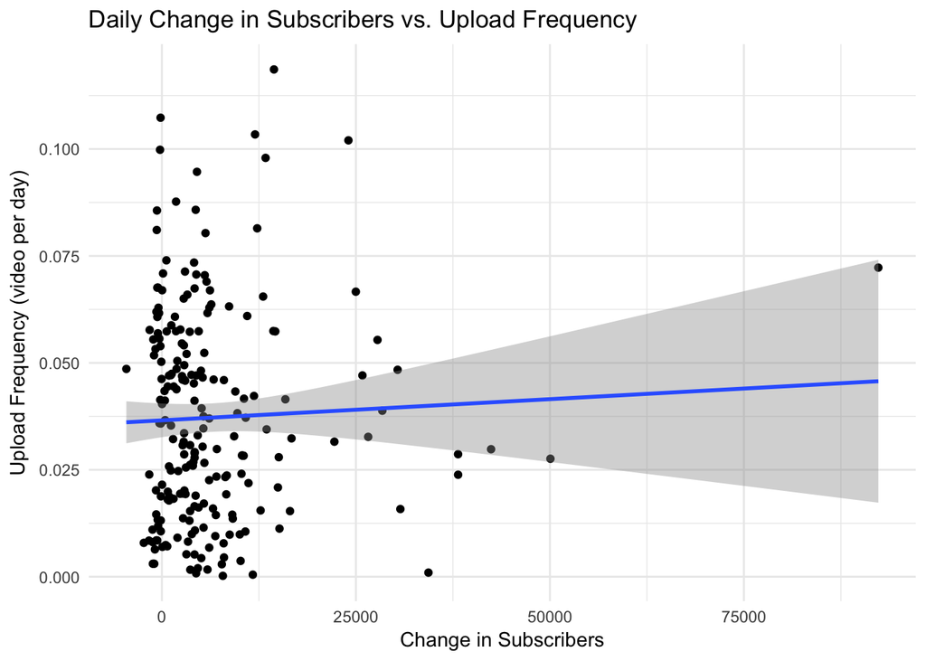

```r
youtube_final_tbl %>%
  filter(daily_subs_avg <= 100000) %>%
  ggplot(aes(x=daily_subs_avg, y=upload_freq)) +
  geom_point() +
  geom_smooth(method="lm") +
  theme_minimal() +
  labs(x = "Change in Subscribers", y = "Upload Frequency (video per day)", title = "Daily Change in Subscribers vs. Upload Frequency")
```

```r
lm(daily_subs_avg~upload_freq, data=youtube_final_tbl) %>%
  broom::tidy()
```

```
##          term   estimate std.error  statistic     p.value
## 1 (Intercept)   9271.431  3053.276  3.0365521 0.002690156
## 2 upload_freq -35289.325 68556.193 -0.5147504 0.607258710
```

This regression clearly shows that there is no relation between the upload frequency and the growth (or decline) of a YouTube channel. The p-value of this regression is 0.6, also indicating that there is *not* strong enough data to indicate a correlation exists. We also filtered out one outlier that made the data hard to see.

Lets try to find a better predictor for the change in average daily views.

```r
lm(daily_views_avg~subscribers+uploads, data=youtube_final_tbl) %>%
  broom::tidy()
```

```
##          term     estimate    std.error statistic    p.value
## 1 (Intercept) 7.043041e+05 6.634371e+05  1.061599 0.28962006
## 2 subscribers 1.409250e-01 5.009989e-02  2.812880 0.00536913
## 3     uploads 4.443861e+01 3.400385e+01  1.306870 0.19266615
```

This regression tries to find a relation between the daily views and a predictor based on the subscribers and uploads. This regression fits significantly better than our previous model, which makes sense. The amount of views that a YouTuber in the top 250 recieves is based off of their current subscribers and the amount of content they have released.

## Conclusion

Throughout this project, we have scraped data from Social Blade, tidyed, determined the spread, variance, and central tendancies of this data. This process led us to running simple regressions with a couple different predictors to find relations to the success of these top YouTubers. While our regressions were not all very successful or in-depth, further models can be made from the data and analysis we have done.

In the future, correlations can be drawn across multiple social platforms (Instagram, Twitter, Twitch, etc.) and compared against each other. Also, this project could be extended further to gather more accurate data if it was made more efficient (fetching views directly from the content creators’ videos).